# Progetto

2023-04-14

```r
library(ggplot2)
library(dplyr)
library(epitools)
library(DescTools)
library(survival)
library(survminer)
library(epiR)
```

### Record linkage - prima parte: da 2 a 6

##### 2. Effettuare il record-linkage con lo scopo di costruire l’indicatore ‘Intervento chirurgico di asportazione del tumore al seno entro 60 giorni dalla data di diagnosi’ su base mensile per i casi incidenti nel mese di gennaio 1984.

```r
#data_deaths =read.csv("dataset/Deathregister.csv", header = TRUE, sep =";")


data_sdo = read.csv("dataset/SDO_clean.csv", header = TRUE, sep =",")

data_cancer = read.csv("dataset/Cancerregister_clean.csv", header=TRUE, sep = ",")

dataMerge=merge(data_cancer, data_sdo, by="idnum")

dataMerge$incidenza = as.Date(dataMerge$incidenza, format = "%Y-%m-%d")
dataMerge$dataprestazione= as.Date(dataMerge$dataprestazione)
dataMerge$dimissione= as.Date(dataMerge$dimissione)

data_gerH = read.csv("dataset/GermanH_clean.csv", header=TRUE, sep = ",")
dataMerge2 = merge(dataMerge, data_gerH, by='idnum')

#pulizia
dataMerge2$Prestazione <- as.factor(dataMerge2$Prestazione)
dataMerge2$ospedale <- as.factor(dataMerge2$ospedale)
dataMerge2$Stadio <- as.factor(dataMerge2$Stadio)
dataMerge2$tipotumore <- as.factor(dataMerge2$tipotumore)
dataMerge2$geneticm <- as.factor(dataMerge2$geneticm)
dataMerge2$smoke <- as.factor(dataMerge2$smoke)
dataMerge2$sex <- as.factor(dataMerge2$sex)
dataMerge2$married <- as.factor(dataMerge2$married)
dataMerge2$kids <- as.factor(dataMerge2$kids)
dataMerge2$work <- as.factor(dataMerge2$work)
dataMerge2$education <- as.factor(dataMerge2$education)

summary(dataMerge2)
```

```
##      idnum             Stadio       incidenza            tipotumore   geneticm
##  Min.   :   3   Stadio I  :1005   Min.   :1984-01-11   altro  :2477   0:5775
##  1st Qu.:1931   Stadio II :3510   1st Qu.:1984-01-13   colon  :1300   1: 604
##  Median :3855   Stadio III: 776   Median :1984-01-15   polmone:1347
##  Mean   :3881   Stadio IV :1088   Mean   :1984-01-15   seno   :1255
##  3rd Qu.:5834                     3rd Qu.:1984-01-18
##  Max.   :7748                     Max.   :1984-01-20
##
##          Prestazione   dataprestazione        dimissione            ospedale
##  chemioterapica:1219   Min.   :1984-01-25   Min.   :1984-06-23   1      : 740
##  chirurgica    :2109   1st Qu.:1984-02-19   1st Qu.:1984-07-17   7      : 724
##  radioterapica :3051   Median :1984-03-08   Median :1984-08-02   8      : 724
##                        Mean   :1984-03-18   Mean   :1984-08-12   6      : 720
##                        3rd Qu.:1984-04-10   3rd Qu.:1984-09-01   9      : 714
##                        Max.   :1984-09-06   Max.   :1985-02-12   5      : 699
##                                                                  (Other):2058
##  smoke          sex       married     kids       work            education
##  no :5090   Female:3203   no :1388   no :3490   no :5983   low        :5717
##  yes:1289   Male  :3176   yes:4991   yes:2889   yes: 396   medium/high: 662
##
##
##
##
##
##       age
##  Min.   : 26.00
##  1st Qu.: 40.00
##  Median : 45.00
##  Mean   : 48.17
##  3rd Qu.: 54.00
##  Max.   :108.00
##
```

Per costruire l’indicatore, il denominatore deve soddisfare i seguenti critieri di inclusione: 1. sex: female 2. tipotumore: seno 3. Stadio: Stadio II, Stadio III 4. intervallo di tempo fra diagnosi e intervento = 60 giorni 5. incidenza: dal 1984-01-01 al 1984-01-31 6. prestazione: chirurgica

Al numeratore invece, verranno incluse solamente le pazienti che hanno subito un intervento entro 60 giorni dalla data d’incidenza. Verrà quindi creata una nuova variabile binaria per indicare la presenza dell’evento o meno.

```r
#denominatore
data = dataMerge2[dataMerge2$sex == 'Female',]
data = data[data$Stadio == 'Stadio II' | data$Stadio == 'Stadio III',]
data = data[data$tipotumore=='seno', ]
data = data[data$Prestazione=='chirurgica',]
summary(data)
```

```
##      idnum             Stadio      incidenza            tipotumore  geneticm
##  Min.   :  18   Stadio I  :  0   Min.   :1984-01-11   altro  :  0   0:261
##  1st Qu.: 863   Stadio II :240   1st Qu.:1984-01-13   colon  :  0   1: 30
##  Median :2016   Stadio III: 51   Median :1984-01-15   polmone:  0
##  Mean   :1910   Stadio IV :  0   Mean   :1984-01-15   seno   :291
##  3rd Qu.:2804                    3rd Qu.:1984-01-17
##  Max.   :3850                    Max.   :1984-01-20
##
##          Prestazione  dataprestazione        dimissione            ospedale
##  chemioterapica:  0   Min.   :1984-01-29   Min.   :1984-06-26   1      :38
##  chirurgica    :291   1st Qu.:1984-02-19   1st Qu.:1984-07-15   4      :38
##  radioterapica :  0   Median :1984-03-02   Median :1984-08-02   6      :37
##                       Mean   :1984-03-16   Mean   :1984-08-14   8      :37
##                       3rd Qu.:1984-04-07   3rd Qu.:1984-09-01   9      :35
##                       Max.   :1984-07-27   Max.   :1985-02-06   3      :29
##                                                                 (Other):77
##  smoke         sex      married    kids      work           education
##  no :229   Female:291   no : 56   no :158   no :275   low        :251
##  yes: 62   Male  :  0   yes:235   yes:133   yes: 16   medium/high: 40
##
##
##
##
##
##       age
##  Min.   :29.00
##  1st Qu.:39.00
##  Median :45.00
##  Mean   :47.68
##  3rd Qu.:53.00
##  Max.   :98.00
##
```

```r
dim(data)
```

```
## [1] 291  16
```

La variabile ‘incidenza’ soddisfa già i criteri di inclusione. Come possiamo notare dalle statistiche descrittive, la data è compresa tra l’11/01/1984 e il 20/01/1984.

Al numeratore verranno incluse tutte le pazienti del denominatore che hanno subito l’intervento entro 60 giorni.

Attraverso il seguente codice, si aggiunge la variabile “intervallo” per calcolare il numero di giorni fra la data di prestazione e la data di incidenza.

```r
data$intervallo = as.numeric(data$dataprestazione - data$incidenza)
summary(data$intervallo)
```

```
##    Min. 1st Qu.  Median    Mean 3rd Qu.    Max.
##    9.00   34.00   47.00   61.12   86.00  193.00
```

Osservando la nuova variabile ‘intervallo’ possiamo notare che il tempo minimo di attesa per la prestazione è pari a 9 giorni, invece il tempo massimo di attesa equivale a 193 giorni.

In seguito, viene creata la variabile binaria ‘intervento60gg’ per individuare le osservazioni che hanno subito o meno l’intervento entro 60 giorni.

```r
data$intervento60gg = ifelse(data$intervallo <= 60, 1, 0)
T1 = table(data$intervento60gg); T1 #indicatore tumore seno
```

```
##
##   0   1
## 105 186
```

```r
prop.table(T1)
```

```
##
##         0         1
## 0.3608247 0.6391753
```

```r
indicatore = T1[2]/(T1[2]+T1[1]) #
indicatore
```

```
##         1
## 0.6391753
```

L’indicatore è pari a 0.63. La percentuale di interventi entro 60 giorni dalla data di diagnosi è pari al 63%.

##### 3. Calcolare l’indicatore ‘Intervento chirurgico di asportazione del tumore al seno entro 60 giorni dalla data di diagnosi’ per ospedale e darne rappresentazione grafica, includendo come valore di riferimento nel grafico l’indicatore calcolato sull’intero dataset. Per esempi relativi alla rappresentazione grafica fare riferimento al sito Piano Nazionale Esiti (PNE) o siti analoghi trattati a lezione.

```r
table(data$ospedale)
```

```
##
##  1  2  3  4  5  6  7  8  9
## 38 28 29 38 22 37 27 37 35
```

```r
#indicatore grezzo
TT<-table(evento = data$intervento60gg, ospedale = data$ospedale);TT
```

```
##       ospedale
## evento  1  2  3  4  5  6  7  8  9
##      0 18 11 10 13  7 14  8 10 14
##      1 20 17 19 25 15 23 19 27 21
```

```r
prop.table(TT,2) #indicatore seconda posizione evento 1
```

```
##       ospedale
## evento         1         2         3         4         5         6         7
##      0 0.4736842 0.3928571 0.3448276 0.3421053 0.3181818 0.3783784 0.2962963
##      1 0.5263158 0.6071429 0.6551724 0.6578947 0.6818182 0.6216216 0.7037037
##       ospedale
## evento         8         9
##      0 0.2702703 0.4000000
##      1 0.7297297 0.6000000
```

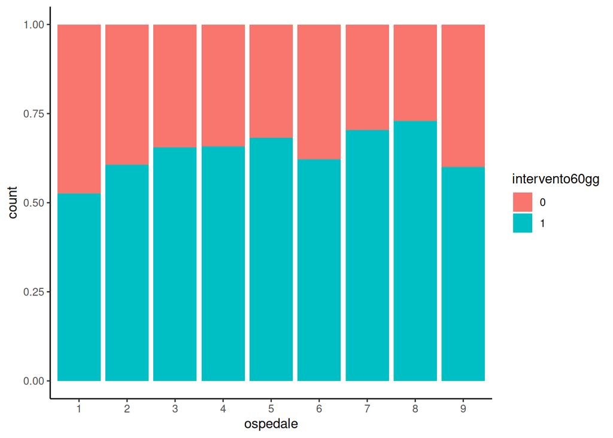

```r
data$intervento60gg = as.factor(data$intervento60gg)
#indicatore grezzo
ggplot(data, aes(x = ospedale, fill = intervento60gg)) +
  geom_bar(position = "fill") +
  theme_classic()
```

Come si evince dal grafico sovrastante, gli ospedali 7 e 8 sono quelli con percentuale maggiore relativa alle osservazioni che hanno subito l’evento, rispettivamente pari a 70% e 73%. L’ospedale 1, invece, presenta la percentuale minore di osservazioni che hanno subito l’evento, pari a 53%.

Nella tabella seguente vengono riportati gli indicatori per ospedale.

```r
indice <- data %>%
  group_by(ospedale)%>%
  summarise(indice=sum(intervento60gg == 1)/n())
indice
```

```
## # A tibble: 9 × 2
##   ospedale indice
##   <fct>     <dbl>
## 1 1         0.526
## 2 2         0.607
## 3 3         0.655
## 4 4         0.658
## 5 5         0.682
## 6 6         0.622
## 7 7         0.704
## 8 8         0.730
## 9 9         0.6
```

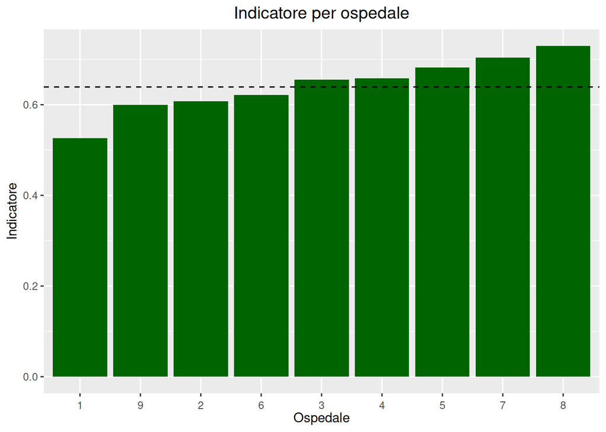

```r
bar_plot = ggplot(indice, aes(x = reorder(ospedale, indice), y = indice)) +
  geom_bar(stat = "identity", fill = "darkgreen") +
  xlab("Ospedale") +
  ylab("Indicatore") +
  ggtitle("Indicatore per ospedale") +
  theme(plot.title = element_text(size = 14, hjust = 0.5),
        axis.text.x = element_text(angle = 0, vjust = 0, hjust=0.5)) +
  geom_hline(yintercept = indicatore, linetype='dashed', color='black')

bar_plot
```

Considerando il valore dell’indicatore di riferimento, calcolato in precedenza sull’intero dataset, pari a 0.63, gli ospedali 3, 4, 5, 7, 8 presentano un valore superiore. Invece, gli ospedali 1, 9, 2, 6 presentano un valore inferiore.

##### 4. Utilizzare il dataset ottenuto per valutare l’associazione a livello individuale tra il livello di educazione ed il valore dell’indicatore ‘Intervento chirurgico di asportazione del tumore al seno entro 60 giorni dalla data di diagnosi’. Quale misura di effetto è possibile stimare? Calcolate ed interpretate tale misura di effetto grezza. Riportare anche la relativa tabella di contingenza.

Per valutare l’associazione tra il livello di educazione e l’intervento chirurgico di asportazione del tumore al seno entro 60 giorni dalla diagnosi, è possibile utilizzare una tabella di contingenza dove vengono riportati i valori che indicano il numero di casi che rientrano in ogni combinazione di categoria di educazione e di intervento chirurgico.

```r
tabella_contingenza <- table(data$education, data$intervento60gg)
tabella_contingenza
```

```
##
##                 0   1
##   low          91 160
##   medium/high  14  26
```

```r
OR <- (tabella_contingenza[1,1]/tabella_contingenza[1,2])/(tabella_contingenza[2,1]/tabella_contingenza[2,2])
OR
```

```
## [1] 1.05625
```

La misura di effetto che è possibile stimare in questo caso è l’odds ratio, esso ci permette di confrontare le probabilità di un evento tra due gruppi. In particolare, in questo caso si vuole confrontare la probabilità che una donna con un basso livello di educazione abbia un intervento chirurgico di asportazione del tumore al seno entro 60 giorni dalla diagnosi con la probabilità che una donna con un medio/alto livello di educazione abbia lo stesso intervento entro lo stesso periodo.

```r
epitab(data$education, data$intervento60gg, method = c("oddsratio"))
```

```
## $tab
##              Outcome
## Predictor      0        p0   1        p1 oddsratio     lower    upper p.value
##   low         91 0.8666667 160 0.8602151   1.00000        NA       NA      NA
##   medium/high 14 0.1333333  26 0.1397849   1.05625 0.5251331 2.124536       1
##
## $measure
## [1] "wald"
##
## $conf.level
## [1] 0.95
##
## $pvalue
## [1] "fisher.exact"
```

Come si evince dal risultato sovrastante, l’odds ratio è pari a 1.05 con un intervallo di confidenza (0.52, 2.13); poiché l’intervallo di confidenza include il valore 1, non è possibile concludere che l’odds ratio sia significativamente diverso da 1.

L’odds ratio può essere calcolato anche attraverso un modello logistico:

```r
modello_logistico_seno <- glm(intervento60gg ~ education, family = binomial(), data = data)
# Riepilogo del modello
summary(modello_logistico_seno)
```

```
##
## Call:
## glm(formula = intervento60gg ~ education, family = binomial(),
##     data = data)
##
## Coefficients:
##                      Estimate Std. Error z value Pr(>|z|)
## (Intercept)           0.56431    0.13130   4.298 1.72e-05 ***
## educationmedium/high  0.05472    0.35655   0.153    0.878
## ---
## Signif. codes:  0 '***' 0.001 '**' 0.01 '*' 0.05 '.' 0.1 ' ' 1
##
## (Dispersion parameter for binomial family taken to be 1)
##
##     Null deviance: 380.56  on 290  degrees of freedom
## Residual deviance: 380.54  on 289  degrees of freedom
## AIC: 384.54
##
## Number of Fisher Scoring iterations: 4
```

```r
#Lettura Coefficienti
exp(cbind("OR" = coef(modello_logistico_seno), confint.default(modello_logistico_seno, level = 0.95)))
```

```
##                            OR     2.5 %   97.5 %
## (Intercept)          1.758242 1.3593085 2.274255
## educationmedium/high 1.056250 0.5251331 2.124536
```

I risultati coincidono nei tre metodi utilizzati.

##### 5. Calcolate la stessa misura di effetto, questa volta aggiustata per la sola variabile ‘working’, mediante il metodo Mantel Haenszel. Interpretate il risultato.

Per calcolare l’OR tramite il metodo Mantel Haenszel viene costruita una tabella di contingenza per i due gruppi in base allo stato lavorativo.

```r
tabella_contingenza_1 <- table(education = data$education, evento = data$intervento60gg, work = data$work)
tabella_contingenza_1
```

```
## , , work = no
##
##              evento
## education       0   1
##   low          83 154
##   medium/high  14  24
##
## , , work = yes
##
##              evento
## education       0   1
##   low           8   6
##   medium/high   0   2
```

Per verificare la possibilità di utilizzare l’OR di Mantel Haenszel viene utilizzato il test di Breslow-Day, il quale testa l’omogeneità degli odds ratio nei due gruppi.

```r
BreslowDayTest(tabella_contingenza_1)
```

```
##
##  Breslow-Day test on Homogeneity of Odds Ratios
##
## data:  tabella_contingenza_1
## X-squared = 2.3145, df = 1, p-value = 0.1282
```

Il test non rifiuta l’ipotesi nulla di omogeneità; si può proseguire nel calcolo dell’OR.

```r
OR_adj <- mantelhaen.test(tabella_contingenza_1, conf.level = 0.95)
OR_adj
```

```
##
##  Mantel-Haenszel chi-squared test without continuity correction
##
## data:  tabella_contingenza_1
## Mantel-Haenszel X-squared = 0.02044, df = 1, p-value = 0.8863
## alternative hypothesis: true common odds ratio is not equal to 1
## 95 percent confidence interval:
##  0.5257986 2.1027424
## sample estimates:
## common odds ratio
##          1.051484
```

L’OR di Mantel Haenszel non è significativamente diverso da 1, controllando per la variabile ‘working’. Inoltre, il rapporto fra l’ odds ratio crudo e quello di mantel haenszel è pari a circa 1.00. Questo significa che lo stato lavorativo non è un confondente nell’associazione tra il livello di educazione e l’intervento chirurgico di asportazione del tumore al seno entro 60 giorni dalla data di diagnosi.

##### 6. Stimate l’associazione a livello individuale tra il livello di educazione ed il valore dell’indicatore, aggiustata per tutte le variabili disponibili che ritenete opportuno inserire come potenziali confondenti, mediante un modello di regressione logistica. Interpretate i risultati. Su quanti soggetti avete effettuato l’analisi? Quali variabili sono associate all’indicatore? In che modo?

```r
#analisi di regressione logistica

modello <- glm(intervento60gg ~ education, data = data, family = binomial())
exp(cbind("OR" = coef(modello), confint.default(modello, level = 0.95)))
```

```
##                            OR     2.5 %   97.5 %
## (Intercept)          1.758242 1.3593085 2.274255
## educationmedium/high 1.056250 0.5251331 2.124536
```

```r
#geneticm
modello_gen<- glm(intervento60gg ~ education + geneticm, data = data, family = binomial())
exp(cbind("OR" = coef(modello_gen), confint.default(modello_gen, level = 0.95)))
```

```
##                            OR     2.5 %   97.5 %
## (Intercept)          1.623353 1.2420173 2.121769
## educationmedium/high 1.059967 0.5246951 2.141301
## geneticm1            2.445264 0.9658282 6.190871
```

```r
ratio_gen = exp(coef(modello)['educationmedium/high'])/exp(coef(modello_gen)['educationmedium/high'])
ratio_gen
```

```
## educationmedium/high
##            0.9964932
```

Una delle variabili che si é ritenuto considerare come confondente è “geneticm”. Ciò nonostante, il rapporto fra l’OR crudo e quello di MH è pari a circa 1.00. Ciò significa che non è un confondente.

```r
#smoke
modello_stadio <- glm(intervento60gg ~ education + Stadio , data = data, family = binomial())
exp(cbind("OR" = coef(modello_stadio), confint.default(modello_stadio, level = 0.95)))
```

```
##                            OR     2.5 %   97.5 %
## (Intercept)          1.536162 1.1642146 2.026940
## educationmedium/high 1.081571 0.5343748 2.189092
## StadioStadio III     2.345863 1.1462802 4.800810
```

```r
ratio_stadio = exp(coef(modello)['educationmedium/high'])/exp(coef(modello_stadio)['educationmedium/high'])
ratio_stadio
```

```
## educationmedium/high
##            0.9765888
```

Un’altra variabile presa in considerazione come possibile confondente è “Stadio”. Si osserva che, anche in questo caso, il rapporto tra fra l’OR crudo e quello di MH è pari a circa 0.98. Ciò significa che la variabile non è un confondente.

Infine, si va a controllare per la variabile ‘age’ suddivisa in 5 intervalli.

```r
#age
classe_1 <- 28
classe_2 <- 42
classe_3 <- 56
classe_4 <- 70
classe_5 <- 84
classe_6 <- 98
data$age_class <- as.factor(cut(data$age, breaks = c(classe_1, classe_2, classe_3, classe_4, classe_5, classe_6), labels = FALSE))
modello_age <- glm(intervento60gg ~ education + age_class, data = data, family = binomial())
exp(cbind("OR" = coef(modello_age), confint.default(modello_age, level = 0.95)))
```

```
##                                OR     2.5 %   97.5 %
## (Intercept)          1.926757e+00 1.2943773 2.868093
## educationmedium/high 1.085909e+00 0.5364092 2.198319
## age_class2           6.708623e-01 0.3954055 1.138214
## age_class3           1.437811e+00 0.6339816 3.260819
## age_class4           1.411930e+00 0.4219439 4.724674
## age_class5           2.988343e+06 0.0000000      Inf
```

```r
ratio_age = exp(coef(modello)['educationmedium/high'])/exp(coef(modello_age)['educationmedium/high'])
ratio_age
```

```
## educationmedium/high
##            0.9726873
```

Anche in questo caso, la variabile scelta, ‘age’, non è un confondente.

L’analisi è stata eseguita su tutte le persone del dataset.

```r
dim(data)
```

```
## [1] 291  19
```

Le persone del dataset sono 291.

### Record linkage - seconda parte: dal punto 7 in poi

##### Considerate ora tutti i tumori al colon insorti nel gennaio 1984. Unire i data-set utili per studiare la mortalità del tumore al colon nei soggetti inclusi nell’estrazione del German health Register (dataset 1).

```r
data_death = read.csv("dataset/Deathregister.csv", header = TRUE, sep =";")
data_cancer = read.csv("dataset/Cancerregister_clean.csv", header=TRUE, sep = ",")
dataMerge3 = merge(data_cancer, data_death, by="idnum")

data_gerH = read.csv("dataset/GermanH_clean.csv", header=TRUE, sep = ",")
dataMerge4 = merge(dataMerge3, data_gerH, by='idnum')

## Pulizia
dataMerge4$incidenza <- as.Date(dataMerge4$incidenza, format = "%Y-%m-%d")
dataMerge4$enddate <- as.Date(dataMerge4$enddate, format = "%Y-%m-%d")
dataMerge4$Stadio <- as.factor(dataMerge4$Stadio)
dataMerge4$tipotumore <- as.factor(dataMerge4$tipotumore)
dataMerge4$geneticm <- as.factor(dataMerge4$geneticm)
dataMerge4$smoke <- as.factor(dataMerge4$smoke)
dataMerge4$sex <- as.factor(dataMerge4$sex)
dataMerge4$married <- as.factor(dataMerge4$married)
dataMerge4$kids <- as.factor(dataMerge4$kids)
dataMerge4$work <- as.factor(dataMerge4$work)
dataMerge4$education <- as.factor(dataMerge4$education)
dataMerge4$dead <- as.factor(dataMerge4$dead)

summary(dataMerge4)
```

```
##      idnum             Stadio       incidenza            tipotumore   geneticm
##  Min.   :   3   Stadio I  :1011   Min.   :1984-01-11   altro  :2497   0:5807
##  1st Qu.:1929   Stadio II :3532   1st Qu.:1984-01-13   colon  :1304   1: 606
##  Median :3855   Stadio III: 777   Median :1984-01-15   polmone:1352
##  Mean   :3880   Stadio IV :1093   Mean   :1984-01-15   seno   :1260
##  3rd Qu.:5831                     3rd Qu.:1984-01-18
##  Max.   :7748                     Max.   :1984-01-20
##  dead        enddate           smoke          sex       married     kids
##  0:3830   Min.   :1984-06-29   no :5113   Female:3220   no :1394   no :3507
##  1:2583   1st Qu.:1985-08-17   yes:1300   Male  :3193   yes:5019   yes:2906
##           Median :1986-11-22
##           Mean   :1986-11-26
##           3rd Qu.:1988-02-21
##           Max.   :1988-12-30
##   work            education         age
##  no :6015   low        :5747   Min.   : 26.00
##  yes: 398   medium/high: 666   1st Qu.: 40.00
##                                Median : 45.00
##                                Mean   : 48.16
##                                3rd Qu.: 54.00
##                                Max.   :108.00
```

##### 7. Selezionate i record relativi ai tumori al colon e stimate la sopravvivenza a 5 anni. Quanti soggetti sono inclusi nell’analisi? Quanti pazienti sono morti nel periodo di interesse? Riportare graficamente la stima di sopravvivenza nei primi 5 anni dalla diagnosi stimata tramite lo stimatore di Kaplan-Meier. Stimare approssimativamente la sopravvivenza mediana.

```r
colon <- dataMerge4[dataMerge4$tipotumore=="colon",]
length(colon[colon$incidenza>colon$enddate])
```

```
## [1] 0
```

```r
dim(colon)
```

```
## [1] 1304   14
```

Nell’analisi sono inclusi 1304 soggetti.

```r
table(colon$dead)
```

```
##
##   0   1
## 597 707
```

Nel periodo di interesse sono morti 707 pazienti.

Si stima la sopravvivenza di Kaplan-Meier, che viene rappresentata graficamente.

```r
colon$survtime <- as.numeric(colon$enddate-colon$incidenza)/365.25

fit<-survfit(Surv(survtime, as.numeric(dead)) ~1,data=colon)
summary(fit)
```

```
## Call: survfit(formula = Surv(survtime, as.numeric(dead)) ~ 1, data = colon)
##
##   time n.risk n.event survival  std.err lower 95% CI upper 95% CI
##  0.515   1304       1    0.999 0.000767        0.998        1.000
##  0.548   1302       1    0.998 0.001084        0.996        1.000
##  0.586   1301       1    0.998 0.001327        0.995        1.000
##  0.589   1300       1    0.997 0.001532        0.994        1.000
##  0.591   1299       1    0.996 0.001713        0.993        1.000
##  0.597   1298       2    0.995 0.002025        0.991        0.999
##  0.608   1296       1    0.994 0.002164        0.990        0.998
##  0.613   1294       1    0.993 0.002294        0.989        0.998
##  0.619   1293       1    0.992 0.002418        0.988        0.997
##  0.641   1289       1    0.992 0.002536        0.987        0.997
##  0.646   1288       1    0.991 0.002648        0.986        0.996
##  0.649   1287       1    0.990 0.002755        0.985        0.995
##  0.660   1286       2    0.988 0.002958        0.983        0.994
##  0.671   1282       1    0.988 0.003055        0.982        0.994
##  0.682   1279       1    0.987 0.003149        0.981        0.993
##  0.687   1275       2    0.985 0.003329        0.979        0.992
##  0.709   1271       1    0.985 0.003415        0.978        0.991
##  0.715   1270       1    0.984 0.003499        0.977        0.991
##  0.731   1269       1    0.983 0.003581        0.976        0.990
##  0.734   1267       1    0.982 0.003662        0.975        0.989
##  0.739   1266       1    0.982 0.003740        0.974        0.989
##  0.758   1264       1    0.981 0.003817        0.973        0.988
##  0.769   1262       1    0.980 0.003892        0.972        0.988
##  0.783   1260       1    0.979 0.003966        0.971        0.987
##  0.805   1254       1    0.978 0.004039        0.971        0.986
##  0.808   1253       2    0.977 0.004181        0.969        0.985
##  0.816   1251       2    0.975 0.004317        0.967        0.984
##  0.830   1249       1    0.974 0.004384        0.966        0.983
##  0.832   1248       2    0.973 0.004514        0.964        0.982
##  0.835   1246       1    0.972 0.004577        0.963        0.981
##  0.841   1243       1    0.971 0.004640        0.962        0.981
##  0.849   1242       1    0.971 0.004702        0.961        0.980
##  0.862   1240       1    0.970 0.004763        0.961        0.979
##  0.873   1237       1    0.969 0.004823        0.960        0.979
##  0.876   1236       2    0.967 0.004941        0.958        0.977
##  0.884   1234       1    0.967 0.004999        0.957        0.977
##  0.887   1233       1    0.966 0.005056        0.956        0.976
```

[output cut: 503 more lines]

```
##  4.775    131       1    0.257 0.016657        0.227        0.292
##  4.789    126       1    0.255 0.016649        0.225        0.290
##  4.791    124       1    0.253 0.016641        0.223        0.288
##  4.794    123       1    0.251 0.016633        0.221        0.286
##  4.797    122       1    0.249 0.016623        0.218        0.284
##  4.802    121       2    0.245 0.016602        0.214        0.280
##  4.816    117       1    0.243 0.016591        0.212        0.278
##  4.819    116       1    0.241 0.016580        0.210        0.276
##  4.824    115       1    0.239 0.016567        0.208        0.273
##  4.838    111       1    0.236 0.016557        0.206        0.271
##  4.854    107       1    0.234 0.016549        0.204        0.269
##  4.893     99       1    0.232 0.016550        0.202        0.267
##  4.895     97       1    0.230 0.016551        0.199        0.264
##  4.901     96       2    0.225 0.016548        0.195        0.260
##  4.942     89       1    0.222 0.016554        0.192        0.257
```

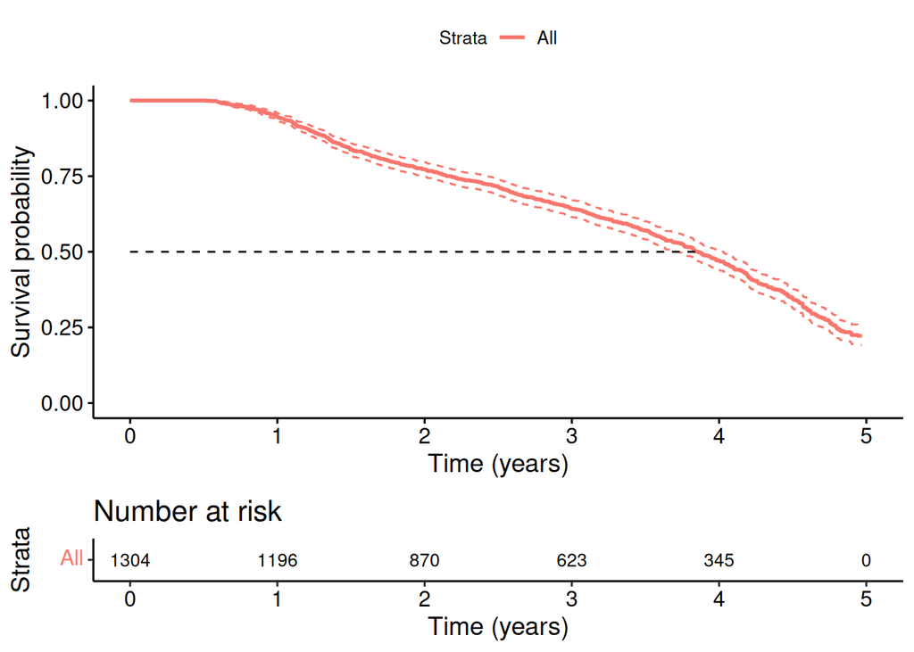

```r
ggsurvplot(fit, data = colon, risk.table = TRUE, conf.int = TRUE, conf.int.fill = "black", conf.int.style = "step", surv.median.line = "h", censor.size=2.5, risk.table.fontsize = 3.5, censor.shape=".", xlab="Time (years)")
```

Nel grafico è riportata la sopravvivenza nei primi 5 anni calcolata con lo stimatore di Kaplan-Meier.

La sopravvivenza mediana, come si osserva nel grafico, è poco inferiore a 4 anni.

##### 8. Stimare la sopravvivenza nei primi 5 anni dalla diagnosi per Stadio e effettuare un test d’ipotesi per verificare se l’azzardo di morte sia diverso per stadio di malattia alla diagnosi.

Si stima la sopravvivenza di Kaplan-Meier per stadio, che viene rappresentata graficamente.

```r
fit<-survfit(Surv(survtime, as.numeric(dead)) ~ Stadio,data=colon)
summary(fit)
```

```
## Call: survfit(formula = Surv(survtime, as.numeric(dead)) ~ Stadio,
##     data = colon)
##
##                 Stadio=Stadio I
##   time n.risk n.event survival std.err lower 95% CI upper 95% CI
##  0.586    228       1    0.996 0.00438        0.987        1.000
##  0.641    225       1    0.991 0.00620        0.979        1.000
##  0.660    224       1    0.987 0.00759        0.972        1.000
##  0.709    220       1    0.982 0.00878        0.965        1.000
##  0.731    219       1    0.978 0.00982        0.959        0.997
##  0.783    218       1    0.973 0.01075        0.952        0.995
##  0.816    216       1    0.969 0.01161        0.946        0.992
##  0.884    213       1    0.964 0.01241        0.940        0.989
##  0.917    212       1    0.960 0.01316        0.934        0.986
##  0.923    211       1    0.955 0.01386        0.928        0.983
##  0.925    210       1    0.951 0.01452        0.923        0.980
##  0.945    208       1    0.946 0.01516        0.917        0.976
##  0.986    207       1    0.941 0.01576        0.911        0.973
##  1.029    205       1    0.937 0.01633        0.905        0.969
##  1.106    203       1    0.932 0.01689        0.900        0.966
##  1.177    202       1    0.928 0.01743        0.894        0.962
##  1.205    200       1    0.923 0.01795        0.888        0.959
##  1.221    198       1    0.918 0.01845        0.883        0.955
##  1.257    196       1    0.914 0.01894        0.877        0.952
##  1.322    192       1    0.909 0.01943        0.872        0.948
##  1.331    190       1    0.904 0.01991        0.866        0.944
##  1.432    185       1    0.899 0.02040        0.860        0.940
##  1.492    184       1    0.894 0.02086        0.854        0.936
##  1.495    183       1    0.889 0.02131        0.849        0.932
##  1.517    182       1    0.885 0.02175        0.843        0.928
##  1.588    177       1    0.880 0.02219        0.837        0.924
##  1.613    174       1    0.875 0.02263        0.831        0.920
##  1.632    173       1    0.869 0.02306        0.825        0.916
##  1.637    172       1    0.864 0.02347        0.820        0.912
##  1.640    171       2    0.854 0.02426        0.808        0.903
##  1.678    167       1    0.849 0.02465        0.802        0.899
##  1.697    165       2    0.839 0.02540        0.791        0.890
##  1.758    161       1    0.834 0.02578        0.785        0.886
##  1.763    160       1    0.828 0.02614        0.779        0.881
##  1.832    157       1    0.823 0.02650        0.773        0.877
```

[output cut: 612 more lines]

```
##  4.572     21       1   0.1184 0.02421       0.0793       0.1768
##  4.575     20       1   0.1125 0.02371       0.0744       0.1700
##  4.591     18       1   0.1063 0.02320       0.0693       0.1630
##  4.602     17       1   0.1000 0.02266       0.0641       0.1559
##  4.616     16       1   0.0938 0.02209       0.0591       0.1488
##  4.649     15       1   0.0875 0.02148       0.0541       0.1416
##  4.668     14       1   0.0813 0.02084       0.0492       0.1343
##  4.704     13       1   0.0750 0.02015       0.0443       0.1270
##  4.717     12       1   0.0688 0.01942       0.0395       0.1196
##  4.753     11       2   0.0563 0.01779       0.0303       0.1045
##  4.789      8       1   0.0492 0.01690       0.0251       0.0965
##  4.794      7       1   0.0422 0.01588       0.0202       0.0882
##  4.797      6       1   0.0352 0.01471       0.0155       0.0798
##  4.802      5       1   0.0281 0.01334       0.0111       0.0713
##  4.824      3       1   0.0188 0.01173       0.0055       0.0639
```

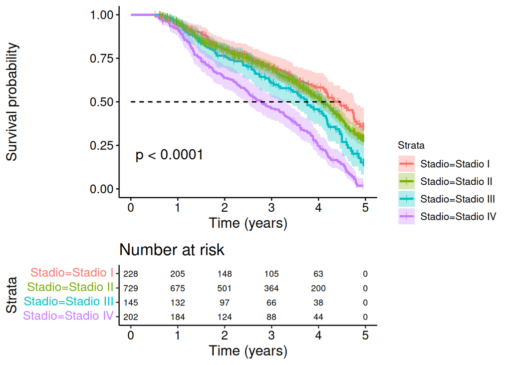

```r
ggsurvplot(fit, data = colon, risk.table = TRUE, conf.int = TRUE, surv.median.line = "h", pval = TRUE, censor.size=2.5, risk.table.fontsize = 3, risk.table.height = 0.35, censor.shape="|", xlab="Time (years)", legend = "right")
```

Dal grafico della sopravvivenza di Kaplan-Meier risulta piuttosto evidente una differenza sul trend della sopravvivenza per stadio.

Si esegue un test di ipotesi log-rank per valutare se la differenza è significativa.

```r
survdiff(Surv(survtime,as.numeric(dead)) ~ Stadio,data=colon)
```

```
## Call:
## survdiff(formula = Surv(survtime, as.numeric(dead)) ~ Stadio,
##     data = colon)
##
##                     N Observed Expected (O-E)^2/E (O-E)^2/V
## Stadio=Stadio I   228       92    126.6     9.448     11.54
## Stadio=Stadio II  729      347    407.1     8.861     20.93
## Stadio=Stadio III 145       85     76.3     0.988      1.11
## Stadio=Stadio IV  202      183     97.0    76.136     88.71
##
##  Chisq= 96  on 3 degrees of freedom, p= <2e-16
```

Il test ha un p-value inferiore a 2e-16, dunque si rigetta l’ipotesi nulla: la differenza tra gli azzardi è statisticamente significativa.

##### 9. Applicare un modello per valutare l’associazione tra sesso e mortalità e interpretare la misura di effetto stimata.

Si applica un modello di regressione logistica per valutare l’associazione.

```r
modello <- glm(dead ~ relevel(sex, "Male"), data = colon, family = binomial())
summary(modello)
```

```
##
## Call:
## glm(formula = dead ~ relevel(sex, "Male"), family = binomial(),
##     data = colon)
##
## Coefficients:
##                            Estimate Std. Error z value Pr(>|z|)
## (Intercept)                 0.38846    0.08081   4.807 1.53e-06 ***
## relevel(sex, "Male")Female -0.42439    0.11189  -3.793 0.000149 ***
## ---
## Signif. codes:  0 '***' 0.001 '**' 0.01 '*' 0.05 '.' 0.1 ' ' 1
##
## (Dispersion parameter for binomial family taken to be 1)
##
##     Null deviance: 1798.4  on 1303  degrees of freedom
## Residual deviance: 1784.0  on 1302  degrees of freedom
## AIC: 1788
##
## Number of Fisher Scoring iterations: 4
```

```r
exp(cbind("OR" = coef(modello), confint.default(modello, level = 0.95)))
```

```
##                                   OR     2.5 %    97.5 %
## (Intercept)                1.4747082 1.2587054 1.7277786
## relevel(sex, "Male")Female 0.6541673 0.5253483 0.8145737
```

La misura di effetto ricavata dal modello è l’ODDS Ratio, pari a 1.53. Ciò significa che gli uomini hanno un valore di ODDS di morte superiore del 50% rispetto alle donne.

##### 10. Quali variabili sono associate alla mortalità? Riportare le relative stime di effetto con gli intervalli di confidenza.

Per studiare l’associazione tra variabili e mortalità si applica un modello di regressione logistica usando come covariate tutte le variabili del dataset.

```r
modello10 <- glm(dead ~ sex + Stadio + geneticm + smoke + married + kids + work + education + age, data = colon, family = binomial())
summary(modello10)
```

```
##
## Call:
## glm(formula = dead ~ sex + Stadio + geneticm + smoke + married +
##     kids + work + education + age, family = binomial(), data = colon)
##
## Coefficients:
##                       Estimate Std. Error z value Pr(>|z|)
## (Intercept)          -6.350105   0.488005 -13.012  < 2e-16 ***
## sexMale               0.534912   0.136367   3.923 8.76e-05 ***
## StadioStadio II       0.549433   0.184347   2.980  0.00288 **
## StadioStadio III      1.126459   0.252291   4.465 8.01e-06 ***
## StadioStadio IV       3.347308   0.306252  10.930  < 2e-16 ***
## geneticm1             2.479183   0.294018   8.432  < 2e-16 ***
## smokeyes              0.502663   0.169317   2.969  0.00299 **
## marriedyes           -0.012706   0.170209  -0.075  0.94050
## kidsyes               0.215680   0.136436   1.581  0.11392
## workyes               0.344326   0.297067   1.159  0.24642
## educationmedium/high  0.761616   0.239466   3.180  0.00147 **
## age                   0.103506   0.008117  12.752  < 2e-16 ***
## ---
## Signif. codes:  0 '***' 0.001 '**' 0.01 '*' 0.05 '.' 0.1 ' ' 1
##
## (Dispersion parameter for binomial family taken to be 1)
##
##     Null deviance: 1798.4  on 1303  degrees of freedom
## Residual deviance: 1312.1  on 1292  degrees of freedom
## AIC: 1336.1
##
## Number of Fisher Scoring iterations: 5
```

```r
exp(cbind("OR" = coef(modello10), confint.default(modello10, level = 0.95)))
```

```
##                                OR        2.5 %       97.5 %
## (Intercept)           0.001746563 6.711094e-04  0.004545434
## sexMale               1.707298637 1.306875e+00  2.230412032
## StadioStadio II       1.732270933 1.206978e+00  2.486178050
## StadioStadio III      3.084715555 1.881330e+00  5.057841673
## StadioStadio IV      28.426112068 1.559680e+01 51.808300309
## geneticm1            11.931508436 6.705430e+00 21.230689195
## smokeyes              1.653117867 1.186264e+00  2.303702118
## marriedyes            0.987374781 7.072937e-01  1.378365206
## kidsyes               1.240704680 9.495842e-01  1.621075913
## workyes               1.411037876 7.882703e-01  2.525818603
## educationmedium/high  2.141734517 1.339465e+00  3.424520661
## age                   1.109051971 1.091548e+00  1.126836304
```

Le variabili che hanno una associazione significativa con la mortalità, e quindi un OR significativamente diverso da 1, sono tutte quelle testate ad eccezione di “married”, “kids” e “work”.

##### 11. Valutare la presenza di confondenti e/o modificatori di effetto tra le variabili disponibili nel German health register e nel registro tumori nella valutazione dell’associazione tra sesso e mortalità. Se identificate un’interazione tra sesso e un’altra variabile riportare le stime di effetto per maschi e femmine separatamente e commentare il tipo di interazione trovato.

Si studia la correlazione tra morti e sesso, valutando la presenza di confondenti o modificatori tramite stratificazione.

La prima variabile studiata come eventuale confondente o modificatore di effetto è il fattore genetico.

```r
cont_table_geneticm <- table(sex = colon$sex,
                             dead = relevel(colon$dead, "1"),
                             genetic = colon$geneticm)
strat_geneticm<-epi.2by2(dat=cont_table_geneticm , method="cohort.count")
strat_geneticm$massoc.detail$RR.strata.wald
```

```
##        est     lower     upper
## 1 0.801979 0.7160920 0.8981671
## 2 1.006040 0.8774716 1.1534458
```

```r
strat_geneticm$massoc.detail$OR.strata.wald
```

```
##         est     lower     upper
## 1 0.6379555 0.5068117 0.8030344
## 2 1.0460526 0.3760059 2.9101304
```

Si osserva una differenza sia tra gli ODDS Ratio che tra i Rischi Relativi. Si verifica se la differenza è significativa tramite il test di omogeneità.

```r
strat_geneticm$massoc.detail$wRR.homog
```

```
##   test.statistic df    p.value
## 1       6.261811  1 0.01233681
```

```r
strat_geneticm$massoc.detail$wOR.homog
```

```
##   test.statistic df   p.value
## 1      0.8725141  1 0.3502602
```

Il test di omogeneità risulta significativo per i Rischi Relativi: il fattore genetico è un modificatore d’effetto per questa misura. Il test di omogeneità sugli OR risulta non significativo.

```r
strat_geneticm
```

```
##              Outcome +    Outcome -      Total                 Inc risk *
## Exposed +          328          340        668     49.10 (45.25 to 52.96)
## Exposed -          379          257        636     59.59 (55.66 to 63.43)
## Total              707          597       1304     54.22 (51.47 to 56.95)
##
##
## Point estimates and 95% CIs:
## -------------------------------------------------------------------
## Inc risk ratio (crude)                         0.82 (0.75, 0.91)
## Inc risk ratio (M-H)                           0.83 (0.75, 0.92)
## Inc risk ratio (crude:M-H)                     0.99
## Odds ratio (crude)                             0.65 (0.53, 0.81)
## Odds ratio (M-H)                               0.65 (0.52, 0.82)
## Odds ratio (crude:M-H)                         1.00
## Attrib risk in the exposed (crude) *           -10.49 (-15.87, -5.11)
## Attrib risk in the exposed (M-H) *             -10.05 (-15.43, -4.66)
## Attrib risk (crude:M-H)                        1.04
## -------------------------------------------------------------------
##  M-H test of homogeneity of IRRs: chi2(1) = 6.262 Pr>chi2 = 0.012
##  M-H test of homogeneity of ORs: chi2(1) = 0.873 Pr>chi2 = 0.350
##  Test that M-H adjusted OR = 1:  chi2(1) = 13.859 Pr>chi2 = <0.001
##  Wald confidence limits
##  M-H: Mantel-Haenszel; CI: confidence interval
##  * Outcomes per 100 population units
```

Il rapporto tra l’OR crudo e l’OR di MH è pari a 1: il fattore genetico non è un confondente per l’OR.

Si valutano i RR separatamente per sesso.

```r
cont_table_geneticm_male <- table(genetic = relevel(colon$geneticm, "1")[colon$sex=="Male"],
                                  dead = relevel(colon$dead, "1")[colon$sex=="Male"])
strat_geneticm_male<-epi.2by2(dat=cont_table_geneticm_male, method="cohort.count")
strat_geneticm_male
```

```
##              Outcome +    Outcome -      Total                 Inc risk *
## Exposed +           57            9         66     86.36 (75.69 to 93.57)
## Exposed -          322          248        570     56.49 (52.31 to 60.61)
## Total              379          257        636     59.59 (55.66 to 63.43)
##
## Point estimates and 95% CIs:
## -------------------------------------------------------------------
## Inc risk ratio                                 1.53 (1.36, 1.72)
## Odds ratio                                     4.88 (2.37, 10.04)
## Attrib risk in the exposed *                   29.87 (20.65, 39.10)
## Attrib fraction in the exposed (%)            34.59 (26.26, 41.98)
## Attrib risk in the population *                3.10 (-2.48, 8.68)
## Attrib fraction in the population (%)         5.20 (3.13, 7.23)
## -------------------------------------------------------------------
## Uncorrected chi2 test that OR = 1: chi2(1) = 21.920 Pr>chi2 = <0.001
## Fisher exact test that OR = 1: Pr>chi2 = <0.001
##  Wald confidence limits
##  CI: confidence interval
##  * Outcomes per 100 population units
```

```r
cont_table_geneticm_female <- table(genetic = relevel(colon$geneticm, "1")[colon$sex=="Female"],
                                    dead = relevel(colon$dead, "1")[colon$sex=="Female"])
strat_geneticm_female<-epi.2by2(dat=cont_table_geneticm_female, method="cohort.count")
strat_geneticm_female
```

```
##              Outcome +    Outcome -      Total                 Inc risk *
## Exposed +           53            8         61     86.89 (75.78 to 94.16)
## Exposed -          275          332        607     45.30 (41.29 to 49.36)
## Total              328          340        668     49.10 (45.25 to 52.96)
##
## Point estimates and 95% CIs:
## -------------------------------------------------------------------
## Inc risk ratio                                 1.92 (1.68, 2.19)
## Odds ratio                                     8.00 (3.74, 17.11)
## Attrib risk in the exposed *                   41.58 (32.23, 50.93)
## Attrib fraction in the exposed (%)            47.86 (40.56, 54.26)
## Attrib risk in the population *                3.80 (-1.69, 9.28)
## Attrib fraction in the population (%)         7.73 (5.10, 10.29)
## -------------------------------------------------------------------
## Uncorrected chi2 test that OR = 1: chi2(1) = 38.346 Pr>chi2 = <0.001
## Fisher exact test that OR = 1: Pr>chi2 = <0.001
##  Wald confidence limits
##  CI: confidence interval
##  * Outcomes per 100 population units
```

Si studia ora la variabile “smoke”.

```r
cont_table_smoke <- table(sex = colon$sex,
                          dead = relevel(colon$dead, "1"),
                          smoke = colon$smoke)
strat_smoke<-epi.2by2(dat=cont_table_smoke , method="cohort.count")
strat_smoke$massoc.detail$RR.strata.wald
```

```
##         est     lower     upper
## 1 0.8094844 0.7204208 0.9095585
## 2 0.8903831 0.7353834 1.0780527
```

```r
strat_smoke$massoc.detail$OR.strata.wald
```

```
##         est     lower     upper
## 1 0.6408747 0.5015922 0.8188332
## 2 0.7373331 0.4475340 1.2147903
```

In questo caso entrambe le misure di effetto sono molto simili in entrambi gli strati. Ci si aspetta che i test non siano significativi.

```r
strat_smoke$massoc.detail$wRR.homog
```

```
##   test.statistic df   p.value
## 1      0.6947805  1 0.4045431
```

```r
strat_smoke$massoc.detail$wOR.homog
```

```
##   test.statistic df  p.value
## 1      0.2509898  1 0.616379
```

In entrambi i casi i test non sono significativi: la variabile non è un modificatore di effetto ed è possibile calcolare una misura di effetto comune tramite il metodo di Mantel Haenszel.

```r
strat_smoke
```

```
##              Outcome +    Outcome -      Total                 Inc risk *
## Exposed +          328          340        668     49.10 (45.25 to 52.96)
## Exposed -          379          257        636     59.59 (55.66 to 63.43)
## Total              707          597       1304     54.22 (51.47 to 56.95)
##
##
## Point estimates and 95% CIs:
## -------------------------------------------------------------------
## Inc risk ratio (crude)                         0.82 (0.75, 0.91)
## Inc risk ratio (M-H)                           0.83 (0.75, 0.91)
## Inc risk ratio (crude:M-H)                     1.00
## Odds ratio (crude)                             0.65 (0.53, 0.81)
## Odds ratio (M-H)                               0.66 (0.53, 0.82)
## Odds ratio (crude:M-H)                         0.99
## Attrib risk in the exposed (crude) *           -10.49 (-15.87, -5.11)
## Attrib risk in the exposed (M-H) *             -10.27 (-15.77, -4.77)
## Attrib risk (crude:M-H)                        1.02
## -------------------------------------------------------------------
##  M-H test of homogeneity of IRRs: chi2(1) = 0.695 Pr>chi2 = 0.405
##  M-H test of homogeneity of ORs: chi2(1) = 0.251 Pr>chi2 = 0.616
##  Test that M-H adjusted OR = 1:  chi2(1) = 13.890 Pr>chi2 = <0.001
##  Wald confidence limits
##  M-H: Mantel-Haenszel; CI: confidence interval
##  * Outcomes per 100 population units
```

Dal rapporto tra l’OR crudo e quello di MH, si evince che la variabile “smoke” non è un confondente per questa misura di effetto. Analogamente accade per il RR.

Si procede ora alla valutazione della variabile “married”.

```r
cont_table_married <- table(sex = colon$sex,
                            dead = relevel(colon$dead, "1"),
                            married = colon$married)
strat_married<-epi.2by2(dat=cont_table_married , method="cohort.count")
strat_married$massoc.detail$RR.strata.wald
```

```
##         est     lower     upper
## 1 0.7352941 0.5892014 0.9176105
## 2 0.8480901 0.7578373 0.9490914
```

```r
strat_married$massoc.detail$OR.strata.wald
```

```
##         est     lower     upper
## 1 0.5000000 0.3042526 0.8216857
## 2 0.6984476 0.5468706 0.8920373
```

```r
strat_married$massoc.detail$wRR.homog
```

```
##   test.statistic df   p.value
## 1       1.267628  1 0.2602122
```

```r
strat_married$massoc.detail$wOR.homog
```

```
##   test.statistic df   p.value
## 1       1.368224  1 0.2421172
```

```r
strat_married
```

```
##              Outcome +    Outcome -      Total                 Inc risk *
## Exposed +          328          340        668     49.10 (45.25 to 52.96)
## Exposed -          379          257        636     59.59 (55.66 to 63.43)
## Total              707          597       1304     54.22 (51.47 to 56.95)
##
##
## Point estimates and 95% CIs:
## -------------------------------------------------------------------
## Inc risk ratio (crude)                         0.82 (0.75, 0.91)
## Inc risk ratio (M-H)                           0.82 (0.75, 0.91)
## Inc risk ratio (crude:M-H)                     1.00
## Odds ratio (crude)                             0.65 (0.53, 0.81)
## Odds ratio (M-H)                               0.65 (0.53, 0.81)
## Odds ratio (crude:M-H)                         1.00
## Attrib risk in the exposed (crude) *           -10.49 (-15.87, -5.11)
## Attrib risk in the exposed (M-H) *             -10.50 (-16.00, -5.00)
## Attrib risk (crude:M-H)                        1.00
## -------------------------------------------------------------------
##  M-H test of homogeneity of IRRs: chi2(1) = 1.268 Pr>chi2 = 0.260
##  M-H test of homogeneity of ORs: chi2(1) = 1.368 Pr>chi2 = 0.242
##  Test that M-H adjusted OR = 1:  chi2(1) = 14.445 Pr>chi2 = <0.001
##  Wald confidence limits
##  M-H: Mantel-Haenszel; CI: confidence interval
##  * Outcomes per 100 population units
```

Si osserva che la variabile non è un confondente né un modificatore di effetto per nessuna delle due misure di effetto calcolate.

Si procede ora alla valutazione della variabile “kids”.

```r
cont_table_kids <- table(sex = colon$sex,
                         dead = relevel(colon$dead, "1"),
                         kids = colon$kids)
strat_kids<-epi.2by2(dat=cont_table_kids , method="cohort.count")
strat_kids$massoc.detail$RR.strata.wald
```

```
##         est     lower     upper
## 1 0.8076923 0.7047437 0.9256796
## 2 0.8448197 0.7286627 0.9794933
```

```r
strat_kids$massoc.detail$OR.strata.wald
```

```
##         est     lower     upper
## 1 0.6301775 0.4695557 0.8457436
## 2 0.6864287 0.4939264 0.9539567
```

```r
strat_kids$massoc.detail$wRR.homog
```

```
##   test.statistic df   p.value
## 1      0.1917273  1 0.6614829
```

```r
strat_kids$massoc.detail$wOR.homog
```

```
##   test.statistic df   p.value
## 1      0.1446491  1 0.7037022
```

```r
strat_kids
```

```
##              Outcome +    Outcome -      Total                 Inc risk *
## Exposed +          328          340        668     49.10 (45.25 to 52.96)
## Exposed -          379          257        636     59.59 (55.66 to 63.43)
## Total              707          597       1304     54.22 (51.47 to 56.95)
##
##
## Point estimates and 95% CIs:
## -------------------------------------------------------------------
## Inc risk ratio (crude)                         0.82 (0.75, 0.91)
## Inc risk ratio (M-H)                           0.82 (0.75, 0.91)
## Inc risk ratio (crude:M-H)                     1.00
## Odds ratio (crude)                             0.65 (0.53, 0.81)
## Odds ratio (M-H)                               0.65 (0.53, 0.82)
## Odds ratio (crude:M-H)                         1.00
## Attrib risk in the exposed (crude) *           -10.49 (-15.87, -5.11)
## Attrib risk in the exposed (M-H) *             -10.47 (-15.97, -4.97)
## Attrib risk (crude:M-H)                        1.00
## -------------------------------------------------------------------
##  M-H test of homogeneity of IRRs: chi2(1) = 0.192 Pr>chi2 = 0.661
##  M-H test of homogeneity of ORs: chi2(1) = 0.145 Pr>chi2 = 0.704
##  Test that M-H adjusted OR = 1:  chi2(1) = 14.377 Pr>chi2 = <0.001
##  Wald confidence limits
##  M-H: Mantel-Haenszel; CI: confidence interval
##  * Outcomes per 100 population units
```

La variabile non è né confondente né modificatore di effetto.

Si procede ora alla valutazione della variabile “work”.

```r
cont_table_work <- table(sex = colon$sex,
                         dead = relevel(colon$dead, "1"),
                         work = colon$work)
strat_work<-epi.2by2(dat=cont_table_work , method="cohort.count")
strat_work$massoc.detail$RR.strata.wald
```

```
##         est     lower     upper
## 1 0.8371720 0.7551517 0.9281009
## 2 0.6252723 0.3954178 0.9887403
```

```r
strat_work$massoc.detail$OR.strata.wald
```

```
##        est     lower     upper
## 1 0.677397 0.5405104 0.8489508
## 2 0.362963 0.1418190 0.9289457
```

```r
strat_work$massoc.detail$wRR.homog
```

```
##   test.statistic df   p.value
## 1       1.483023  1 0.2233021
```

```r
strat_work$massoc.detail$wOR.homog
```

```
##   test.statistic df   p.value
## 1       1.510606  1 0.2190466
```

```r
strat_work
```

```
##              Outcome +    Outcome -      Total                 Inc risk *
## Exposed +          328          340        668     49.10 (45.25 to 52.96)
## Exposed -          379          257        636     59.59 (55.66 to 63.43)
## Total              707          597       1304     54.22 (51.47 to 56.95)
##
##
## Point estimates and 95% CIs:
## -------------------------------------------------------------------
## Inc risk ratio (crude)                         0.82 (0.75, 0.91)
## Inc risk ratio (M-H)                           0.82 (0.74, 0.91)
## Inc risk ratio (crude:M-H)                     1.00
## Odds ratio (crude)                             0.65 (0.53, 0.81)
## Odds ratio (M-H)                               0.65 (0.53, 0.81)
## Odds ratio (crude:M-H)                         1.00
## Attrib risk in the exposed (crude) *           -10.49 (-15.87, -5.11)
## Attrib risk in the exposed (M-H) *             -10.49 (-15.99, -5.00)
## Attrib risk (crude:M-H)                        1.00
## -------------------------------------------------------------------
##  M-H test of homogeneity of IRRs: chi2(1) = 1.483 Pr>chi2 = 0.223
##  M-H test of homogeneity of ORs: chi2(1) = 1.511 Pr>chi2 = 0.219
##  Test that M-H adjusted OR = 1:  chi2(1) = 14.414 Pr>chi2 = <0.001
##  Wald confidence limits
##  M-H: Mantel-Haenszel; CI: confidence interval
##  * Outcomes per 100 population units
```

La variabile non è né confondente né modificatore di effetto.

Si procede ora alla valutazione della variabile “education”.

```r
cont_table_education <- table(sex = colon$sex,
                              dead = relevel(colon$dead, "1"),
                              education = colon$education)
strat_education<-epi.2by2(dat=cont_table_education , method="cohort.count")
strat_education$massoc.detail$RR.strata.wald
```

```
##         est     lower     upper
## 1 0.7946254 0.7133511 0.8851595
## 2 1.1481481 0.8916910 1.4783644
```

```r
strat_education$massoc.detail$OR.strata.wald
```

```
##        est     lower    upper
## 1 0.612000 0.4863317 0.770141
## 2 1.533333 0.6976555 3.370017
```

```r
strat_education$massoc.detail$wRR.homog
```

```
##   test.statistic df    p.value
## 1       6.887831  1 0.00867845
```

```r
strat_education$massoc.detail$wOR.homog
```

```
##   test.statistic df    p.value
## 1       4.791631  1 0.02859834
```

Il test sull’omogeneità dei Rischi Relativi è significativo: la variabile è un modificatore di effetto per il RR.

```r
strat_education
```

```
##              Outcome +    Outcome -      Total                 Inc risk *
## Exposed +          328          340        668     49.10 (45.25 to 52.96)
## Exposed -          379          257        636     59.59 (55.66 to 63.43)
## Total              707          597       1304     54.22 (51.47 to 56.95)
##
##
## Point estimates and 95% CIs:
## -------------------------------------------------------------------
## Inc risk ratio (crude)                         0.82 (0.75, 0.91)
## Inc risk ratio (M-H)                           0.83 (0.75, 0.91)
## Inc risk ratio (crude:M-H)                     1.00
## Odds ratio (crude)                             0.65 (0.53, 0.81)
## Odds ratio (M-H)                               0.66 (0.53, 0.82)
## Odds ratio (crude:M-H)                         0.99
## Attrib risk in the exposed (crude) *           -10.49 (-15.87, -5.11)
## Attrib risk in the exposed (M-H) *             -10.26 (-15.78, -4.74)
## Attrib risk (crude:M-H)                        1.02
## -------------------------------------------------------------------
##  M-H test of homogeneity of IRRs: chi2(1) = 6.888 Pr>chi2 = 0.009
##  M-H test of homogeneity of ORs: chi2(1) = 4.792 Pr>chi2 = 0.029
##  Test that M-H adjusted OR = 1:  chi2(1) = 13.878 Pr>chi2 = <0.001
##  Wald confidence limits
##  M-H: Mantel-Haenszel; CI: confidence interval
##  * Outcomes per 100 population units
```

“education” non è un confondente per l’OR.

Si procede a stimare il RR per maschi e femmine separatamente.

```r
cont_table_education_male <- table(education = relevel(colon$education, "medium/high")[colon$sex=="Male"],
                                   dead = relevel(colon$dead, "1")[colon$sex=="Male"])
strat_education_male<-epi.2by2(dat=cont_table_education_male, method="cohort.count")
strat_education_male
```

```
##              Outcome +    Outcome -      Total                 Inc risk *
## Exposed +           39           23         62     62.90 (49.69 to 74.84)
## Exposed -          340          234        574     59.23 (55.09 to 63.28)
## Total              379          257        636     59.59 (55.66 to 63.43)
##
## Point estimates and 95% CIs:
## -------------------------------------------------------------------
## Inc risk ratio                                 1.06 (0.87, 1.30)
## Odds ratio                                     1.17 (0.68, 2.01)
## Attrib risk in the exposed *                   3.67 (-9.01, 16.35)
## Attrib fraction in the exposed (%)            5.83 (-15.34, 23.12)
## Attrib risk in the population *                0.36 (-5.18, 5.90)
## Attrib fraction in the population (%)         0.60 (-1.50, 2.66)
## -------------------------------------------------------------------
## Uncorrected chi2 test that OR = 1: chi2(1) = 0.313 Pr>chi2 = 0.576
## Fisher exact test that OR = 1: Pr>chi2 = 0.683
##  Wald confidence limits
##  CI: confidence interval
##  * Outcomes per 100 population units
```

```r
cont_table_education_female <- table(education = relevel(colon$education, "medium/high")[colon$sex=="Female"],
                                     dead = relevel(colon$dead, "1")[colon$sex=="Female"])
strat_education_female<-epi.2by2(dat=cont_table_education_female, method="cohort.count")
strat_education_female
```

```
##              Outcome +    Outcome -      Total                 Inc risk *
## Exposed +           39           15         54     72.22 (58.36 to 83.54)
## Exposed -          289          325        614     47.07 (43.06 to 51.10)
## Total              328          340        668     49.10 (45.25 to 52.96)
##
## Point estimates and 95% CIs:
## -------------------------------------------------------------------
## Inc risk ratio                                 1.53 (1.27, 1.85)
## Odds ratio                                     2.92 (1.58, 5.41)
## Attrib risk in the exposed *                   25.15 (12.57, 37.74)
## Attrib fraction in the exposed (%)            34.83 (21.55, 45.86)
## Attrib risk in the population *                2.03 (-3.44, 7.51)
## Attrib fraction in the population (%)         4.14 (1.77, 6.46)
## -------------------------------------------------------------------
## Uncorrected chi2 test that OR = 1: chi2(1) = 12.566 Pr>chi2 = <0.001
## Fisher exact test that OR = 1: Pr>chi2 = <0.001
##  Wald confidence limits
##  CI: confidence interval
##  * Outcomes per 100 population units
```

Si procede ora alla valutazione della variabile “Stadio”.

```r
cont_table_stadio <- table(sex = colon$sex,
                    dead = relevel(colon$dead, "1"),
                    stadio = colon$Stadio)
strat_stadio<-epi.2by2(dat=cont_table_stadio , method="cohort.count")
strat_stadio$massoc.detail$RR.strata.wald
```

```
##         est     lower    upper
## 1 0.5356668 0.3791356 0.756824
## 2 0.8676668 0.7451599 1.010314
## 3 0.9116279 0.6936136 1.198168
## 4 0.9023913 0.8238410 0.988431
```

```r
strat_stadio$massoc.detail$OR.strata.wald
```

```
##         est     lower     upper
## 1 0.3557377 0.2050549 0.6171485
## 2 0.7620488 0.5692676 1.0201148
## 3 0.7991543 0.4118332 1.5507434
## 4 0.3097668 0.1071449 0.8955670
```

```r
strat_stadio$massoc.detail$wRR.homog
```

```
##   test.statistic df    p.value
## 1       8.281237  3 0.04054328
```

```r
strat_stadio$massoc.detail$wOR.homog
```

```
##   test.statistic df    p.value
## 1       7.721106  3 0.05214136
```

```r
strat_stadio
```

```
##              Outcome +    Outcome -      Total                 Inc risk *
## Exposed +          328          340        668     49.10 (45.25 to 52.96)
## Exposed -          379          257        636     59.59 (55.66 to 63.43)
## Total              707          597       1304     54.22 (51.47 to 56.95)
##
##
## Point estimates and 95% CIs:
## -------------------------------------------------------------------
## Inc risk ratio (crude)                         0.82 (0.75, 0.91)
## Inc risk ratio (M-H)                           0.83 (0.75, 0.91)
## Inc risk ratio (crude:M-H)                     0.99
## Odds ratio (crude)                             0.65 (0.53, 0.81)
## Odds ratio (M-H)                               0.63 (0.50, 0.80)
## Odds ratio (crude:M-H)                         1.03
## Attrib risk in the exposed (crude) *           -10.49 (-15.87, -5.11)
## Attrib risk in the exposed (M-H) *             -10.06 (-15.27, -4.86)
## Attrib risk (crude:M-H)                        1.04
## -------------------------------------------------------------------
##  M-H test of homogeneity of IRRs: chi2(3) = 8.281 Pr>chi2 = 0.041
##  M-H test of homogeneity of ORs: chi2(3) = 7.721 Pr>chi2 = 0.052
##  Test that M-H adjusted OR = 1:  chi2(1) = 14.826 Pr>chi2 = <0.001
##  Wald confidence limits
##  M-H: Mantel-Haenszel; CI: confidence interval
##  * Outcomes per 100 population units
```

```r
model_bin_male <- glm(dead ~ Stadio, data=colon[colon$sex=="Male",], family="binomial")
summary(model_bin_male)
```

```
##
## Call:
## glm(formula = dead ~ Stadio, family = "binomial", data = colon[colon$sex ==
##     "Male", ])
##
## Coefficients:
##                  Estimate Std. Error z value Pr(>|z|)
## (Intercept)       0.08552    0.18507   0.462    0.644
## StadioStadio II  -0.03927    0.21405  -0.183    0.854
## StadioStadio III  0.37984    0.30748   1.235    0.217
## StadioStadio IV   2.89001    0.49440   5.846 5.05e-09 ***
## ---
## Signif. codes:  0 '***' 0.001 '**' 0.01 '*' 0.05 '.' 0.1 ' ' 1
##
## (Dispersion parameter for binomial family taken to be 1)
##
##     Null deviance: 858.14  on 635  degrees of freedom
## Residual deviance: 774.81  on 632  degrees of freedom
## AIC: 782.81
##
## Number of Fisher Scoring iterations: 5
```

```r
exp(cbind("Odds ratio" = coef(model_bin_male), confint.default(model_bin_male, level = 0.95)))
```

```
##                  Odds ratio     2.5 %    97.5 %
## (Intercept)        1.089286 0.7578978  1.565572
## StadioStadio II    0.961490 0.6320406  1.462664
## StadioStadio III   1.462052 0.8002693  2.671097
## StadioStadio IV   17.993442 6.8278473 47.418162
```

```r
model_bin_female <- glm(dead ~ Stadio, data=colon[colon$sex=="Female",], family="binomial")
summary(model_bin_female)
```

```
##
## Call:
## glm(formula = dead ~ Stadio, family = "binomial", data = colon[colon$sex ==
##     "Female", ])
##
## Coefficients:
##                  Estimate Std. Error z value Pr(>|z|)
## (Intercept)       -0.9480     0.2116  -4.481 7.42e-06 ***
## StadioStadio II    0.7225     0.2352   3.072 0.002129 **
## StadioStadio III   1.1892     0.3144   3.782 0.000156 ***
## StadioStadio IV    2.7516     0.3577   7.693 1.44e-14 ***
## ---
## Signif. codes:  0 '***' 0.001 '**' 0.01 '*' 0.05 '.' 0.1 ' ' 1
##
## (Dispersion parameter for binomial family taken to be 1)
##
##     Null deviance: 925.83  on 667  degrees of freedom
## Residual deviance: 841.18  on 664  degrees of freedom
## AIC: 849.18
##
## Number of Fisher Scoring iterations: 4
```

```r
exp(cbind("Odds ratio" = coef(model_bin_female), confint.default(model_bin_female, level = 0.95)))
```

```
##                  Odds ratio    2.5 %     97.5 %
## (Intercept)        0.387500 0.255971  0.5866143
## StadioStadio II    2.059670 1.298870  3.2660997
## StadioStadio III   3.284457 1.773432  6.0829298
## StadioStadio IV   15.668203 7.772166 31.5861216
```

Gli uomini hanno un OR minore tra Stadio 1 e 2 e tra Stadio 1 e 3 rispetto alle donne. Hanno invece un OR maggiore tra Stadio 1 e 4 rispetto alle donne.

Si procede alla stima dei RR.

```r
model_pois_male <- glm(I(as.numeric(dead)-1) ~ Stadio, data = colon[colon$sex=="Male",], family = poisson)
exp(cbind("Relative risk" = coef(model_pois_male), confint.default(model_pois_male, level = 0.95)))
```

```
##                  Relative risk     2.5 %    97.5 %
## (Intercept)          0.5213675 0.4056570 0.6700836
## StadioStadio II      0.9811902 0.7334593 1.3125939
## StadioStadio III     1.1782201 0.7975066 1.7406786
## StadioStadio IV      1.8249244 1.3256372 2.5122628
```

```r
model_pois_female <- glm(I(as.numeric(dead)-1) ~ Stadio, data = colon[colon$sex=="Female",], family = poisson)
exp(cbind("Relative risk" = coef(model_pois_female), confint.default(model_pois_female, level = 0.95)))
```

```
##                  Relative risk     2.5 %    97.5 %
## (Intercept)          0.2792793 0.1964111 0.3971106
## StadioStadio II      1.5893203 1.0838833 2.3304530
## StadioStadio III     2.0051613 1.2606733 3.1893052
## StadioStadio IV      3.0742913 2.0377728 4.6380377
```

Gli uomini hanno in tutti i casi un RR minore rispetto alle donne: prendendo come riferimento il livello “Male”, si ha dunque una interazione negativa.

Si procede ora alla valutazione della variabile “age”.

```r
model <- glm(dead ~ relevel(sex, "Male") + age, data=colon, family="binomial")
summary(model)
```

```
##
## Call:
## glm(formula = dead ~ relevel(sex, "Male") + age, family = "binomial",
##     data = colon)
##
## Coefficients:
##                             Estimate Std. Error z value Pr(>|z|)
## (Intercept)                -3.265264   0.329073  -9.923  < 2e-16 ***
## relevel(sex, "Male")Female -0.499763   0.119351  -4.187 2.82e-05 ***
## age                         0.077515   0.006909  11.219  < 2e-16 ***
## ---
## Signif. codes:  0 '***' 0.001 '**' 0.01 '*' 0.05 '.' 0.1 ' ' 1
##
## (Dispersion parameter for binomial family taken to be 1)
##
##     Null deviance: 1798.4  on 1303  degrees of freedom
## Residual deviance: 1621.4  on 1301  degrees of freedom
## AIC: 1627.4
##
## Number of Fisher Scoring iterations: 4
```

```r
model2 <- glm(dead ~ relevel(sex, "Male") * age, data=colon, family="binomial")
summary(model2)
```

```
##
## Call:
## glm(formula = dead ~ relevel(sex, "Male") * age, family = "binomial",
##     data = colon)
##
## Coefficients:
##                                Estimate Std. Error z value Pr(>|z|)
## (Intercept)                    -3.71591    0.50153  -7.409 1.27e-13 ***
## relevel(sex, "Male")Female      0.30546    0.66477   0.459    0.646
## age                             0.08734    0.01079   8.091 5.92e-16 ***
## relevel(sex, "Male")Female:age -0.01729    0.01406  -1.229    0.219
## ---
## Signif. codes:  0 '***' 0.001 '**' 0.01 '*' 0.05 '.' 0.1 ' ' 1
##
## (Dispersion parameter for binomial family taken to be 1)
##
##     Null deviance: 1798.4  on 1303  degrees of freedom
## Residual deviance: 1619.9  on 1300  degrees of freedom
## AIC: 1627.9
##
## Number of Fisher Scoring iterations: 4
```

```r
anova(model,model2,test="LRT")
```

```
## Analysis of Deviance Table
##
## Model 1: dead ~ relevel(sex, "Male") + age
## Model 2: dead ~ relevel(sex, "Male") * age
##   Resid. Df Resid. Dev Df Deviance Pr(>Chi)
## 1      1301     1621.4
## 2      1300     1619.9  1   1.5265   0.2166
```

Si osserva che l’interazione non è significativa, secondo il test LRT: age non è un modificatore di effetto.

```r
model3 <- glm(dead ~ relevel(sex, "Male"), data=colon, family="binomial")
or_crude <- exp(cbind("Crude Odds ratio" = coef(model3), confint.default(model3, level = 0.95)))
or_mh <- exp(cbind("MH Odds ratio" = coef(model), confint.default(model, level = 0.95)))
ratio <- or_crude[2]/or_mh[2]
ratio
```

```
## [1] 1.078284
```

Il rapporto tra i due OR è pari a 1.08. Tenendo come valore limite per il confondimento uno scostamento del 10%, è possibile affermare che non c’è confondimento da parte della variabile “age”.

Risultano quindi modificatori di effetto le variabili “geneticm”, “education” e “Stadio”.

##### 12. A seguito delle considerazioni effettuate nei punti precedenti scegliete un modello finale per valutare i fattori di rischio della mortalità dopo diagnosi di tumore al colon e commentate i risultati.

Poiché lo studio è uno studio di mortalità, si utilizza il modello di Cox per tenere conto anche dei diversi tempi di mortalità. Come covariate si scelgono le variabili risultate significative nel punto 10.

```r
model_cox <- coxph(Surv(survtime, I(as.numeric(dead)-1)) ~ relevel(sex, "Male") + geneticm + education + Stadio + smoke + age, data=colon)
summary(model_cox)
```

```
## Call:
## coxph(formula = Surv(survtime, I(as.numeric(dead) - 1)) ~ relevel(sex,
##     "Male") + geneticm + education + Stadio + smoke + age, data = colon)
##
##   n= 1304, number of events= 707
##
##                                 coef exp(coef)  se(coef)      z Pr(>|z|)
## relevel(sex, "Male")Female -0.229161  0.795201  0.075711 -3.027 0.002472 **
## geneticm1                   0.651468  1.918356  0.105263  6.189 6.06e-10 ***
## educationmedium/high        0.230023  1.258629  0.120673  1.906 0.056628 .
## StadioStadio II             0.219986  1.246059  0.117630  1.870 0.061464 .
## StadioStadio III            0.559991  1.750656  0.151482  3.697 0.000218 ***
## StadioStadio IV             0.966904  2.629789  0.128614  7.518 5.57e-14 ***
## smokeyes                    0.118113  1.125372  0.089690  1.317 0.187872
## age                         0.030334  1.030799  0.003097  9.794  < 2e-16 ***
## ---
## Signif. codes:  0 '***' 0.001 '**' 0.01 '*' 0.05 '.' 0.1 ' ' 1
##
##                            exp(coef) exp(-coef) lower .95 upper .95
## relevel(sex, "Male")Female    0.7952     1.2575    0.6855    0.9224
## geneticm1                     1.9184     0.5213    1.5607    2.3579
## educationmedium/high          1.2586     0.7945    0.9935    1.5945
## StadioStadio II               1.2461     0.8025    0.9895    1.5692
## StadioStadio III              1.7507     0.5712    1.3009    2.3558
## StadioStadio IV               2.6298     0.3803    2.0438    3.3837
## smokeyes                      1.1254     0.8886    0.9440    1.3417
## age                           1.0308     0.9701    1.0246    1.0371
##
## Concordance= 0.657  (se = 0.011 )
## Likelihood ratio test= 211.3  on 8 df,   p=<2e-16
## Wald test            = 233.7  on 8 df,   p=<2e-16
## Score (logrank) test = 241.9  on 8 df,   p=<2e-16
```

I test di ipotesi riportano che il modello di Cox è significativo. In particolare, risultano significative le variabili “sex”, “geneticm”, “Stadio”, “age”. “education” è al limite della significatività. “smoke” risulta non significativamente associata.

L’Hazard Ratio risulta significativamente superiore a 1 per le variabili “geneticm”, “Stadio III”, “Stadio IV” e “age”. Queste variabili sono positivamente associate con il rischio di mortalità. L’Hazard Ratio risulta invece significativamente inferiore a 1 per la variabile “sex”. Le restanti variabili hanno un Hazard Ratio non significativamente diverso da 1.

Il modello di Cox assume che l’Hazard Ratio rimanga costante nel tempo. Si verifica questo assunto.

```r
ph_test <- cox.zph(model_cox)
print(ph_test)
```

```
##                       chisq df    p
## relevel(sex, "Male")  0.155  1 0.69
## geneticm              1.643  1 0.20
## education             1.224  1 0.27
## Stadio                5.276  3 0.15
## smoke                 0.196  1 0.66
## age                   2.292  1 0.13
## GLOBAL               11.370  8 0.18
```

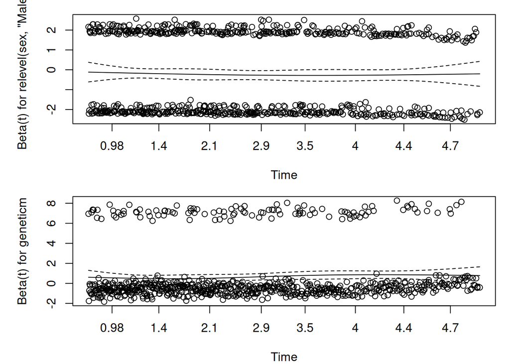

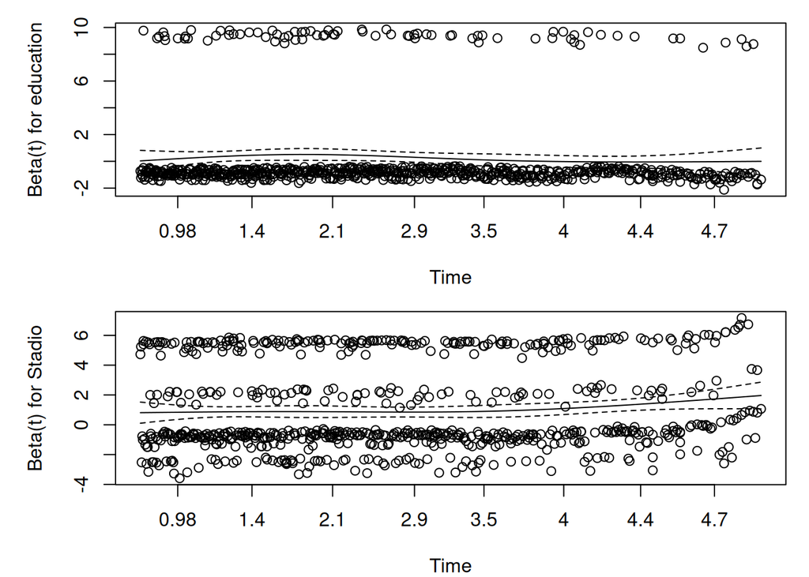

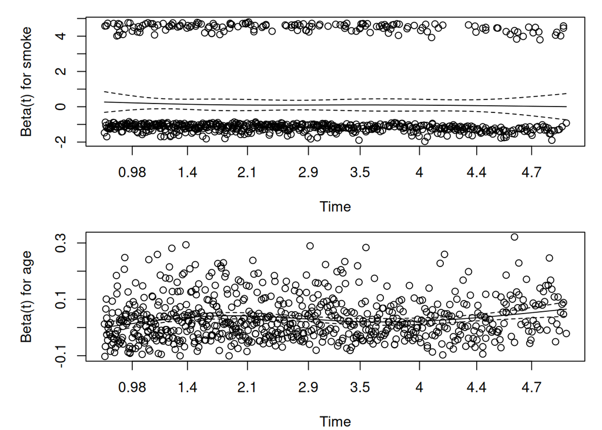

```r
par(mfrow=c(2,1), mar=c(4,5,1,1))
plot(ph_test)
```

L’assunto è verificato per tutte le variabili prese singolarmente e per il modello nel suo complesso. Infatti, dai dati si può notare come il p-value non risulti significativo.

Si inseriscono ora nel modello le modifiche di effetto studiate nel punto 11.

```r
model_cox_2 <- coxph(Surv(survtime, I(as.numeric(dead)-1)) ~ relevel(sex, "Male") * geneticm + relevel(sex, "Male") * education + relevel(sex, "Male") * Stadio + smoke + age, data=colon)
summary(model_cox_2)
```

```
## Call:
## coxph(formula = Surv(survtime, I(as.numeric(dead) - 1)) ~ relevel(sex,
##     "Male") * geneticm + relevel(sex, "Male") * education + relevel(sex,
##     "Male") * Stadio + smoke + age, data = colon)
##
##   n= 1304, number of events= 707
##
##                                                      coef exp(coef)  se(coef)
## relevel(sex, "Male")Female                      -0.846156  0.429061  0.223167
## geneticm1                                        0.439997  1.552702  0.147239
## educationmedium/high                             0.025085  1.025402  0.169617
## StadioStadio II                                 -0.055337  0.946167  0.149072
## StadioStadio III                                 0.253719  1.288810  0.199608
## StadioStadio IV                                  0.818434  2.266948  0.165040
## smokeyes                                         0.108477  1.114579  0.090417
## age                                              0.030156  1.030616  0.003102
## relevel(sex, "Male")Female:geneticm1             0.393981  1.482872  0.211899
## relevel(sex, "Male")Female:educationmedium/high  0.420038  1.522020  0.243128
## relevel(sex, "Male")Female:StadioStadio II       0.641247  1.898848  0.246193
## relevel(sex, "Male")Female:StadioStadio III      0.712925  2.039949  0.310139
## relevel(sex, "Male")Female:StadioStadio IV       0.410593  1.507712  0.267468
##                                                      z Pr(>|z|)
## relevel(sex, "Male")Female                      -3.792  0.00015 ***
## geneticm1                                        2.988  0.00281 **
## educationmedium/high                             0.148  0.88243
## StadioStadio II                                 -0.371  0.71048
## StadioStadio III                                 1.271  0.20370
## StadioStadio IV                                  4.959 7.09e-07 ***
## smokeyes                                         1.200  0.23024
## age                                              9.721  < 2e-16 ***
## relevel(sex, "Male")Female:geneticm1             1.859  0.06299 .
## relevel(sex, "Male")Female:educationmedium/high  1.728  0.08405 .
## relevel(sex, "Male")Female:StadioStadio II       2.605  0.00920 **
## relevel(sex, "Male")Female:StadioStadio III      2.299  0.02152 *
## relevel(sex, "Male")Female:StadioStadio IV       1.535  0.12476
## ---
## Signif. codes:  0 '***' 0.001 '**' 0.01 '*' 0.05 '.' 0.1 ' ' 1
##
##                                                 exp(coef) exp(-coef) lower .95
## relevel(sex, "Male")Female                         0.4291     2.3307    0.2771
```

[output cut: 16 more lines]

```
## StadioStadio II                                    1.2672
## StadioStadio III                                   1.9059
## StadioStadio IV                                    3.1327
## smokeyes                                           1.3307
## age                                                1.0369
## relevel(sex, "Male")Female:geneticm1               2.2463
## relevel(sex, "Male")Female:educationmedium/high    2.4512
## relevel(sex, "Male")Female:StadioStadio II         3.0765
## relevel(sex, "Male")Female:StadioStadio III        3.7464
## relevel(sex, "Male")Female:StadioStadio IV         2.5468
##
## Concordance= 0.663  (se = 0.011 )
## Likelihood ratio test= 226.9  on 13 df,   p=<2e-16
## Wald test            = 244.5  on 13 df,   p=<2e-16
## Score (logrank) test = 257.4  on 13 df,   p=<2e-16
```

I test di ipotesi riportano che il modello di Cox è significativo. In particolare, risultano significative le variabili “sex”, “geneticm”, “Stadio” per il quarto livello e “age”. “education” e “smoke” risultano non significativamente associate. In merito alle interazioni inserite nel modello, risultano significative quelle tra “sex” e “Stadio II” e tra “sex” e “Stadio III”.

L’Hazard Ratio risulta significativamente superiore a 1 per le variabili “geneticm”, “Stadio IV” e “age” e per le interazioni tra “sex” e “Stadio II” e tra “sex” e “Stadio III”. Queste variabili sono positivamente associate con il rischio di mortalità. L’Hazard Ratio risulta invece significativamente inferiore a 1 per la variabile “sex”. Le restanti variabili hanno un Hazard Ratio non significativamente diverso da 1.

```r
anova(model_cox, model_cox_2, test="LRT")
```

```
## Analysis of Deviance Table
##  Cox model: response is  Surv(survtime, I(as.numeric(dead) - 1))
##  Model 1: ~ relevel(sex, "Male") + geneticm + education + Stadio + smoke + age
##  Model 2: ~ relevel(sex, "Male") * geneticm + relevel(sex, "Male") * education + relevel(sex, "Male") * Stadio + smoke + age
##    loglik  Chisq Df Pr(>|Chi|)
## 1 -4422.6
## 2 -4414.8 15.622  5   0.008009 **
## ---
## Signif. codes:  0 '***' 0.001 '**' 0.01 '*' 0.05 '.' 0.1 ' ' 1
```

I due modelli sono significativamente diversi.

```r
ph_test_2 <- cox.zph(model_cox_2)
print(ph_test_2)
```

```
##                                 chisq df     p
## relevel(sex, "Male")            0.106  1 0.745
## geneticm                        1.397  1 0.237
## education                       1.283  1 0.257
## Stadio                          5.286  3 0.152
## smoke                           0.343  1 0.558
## age                             2.484  1 0.115
## relevel(sex, "Male"):geneticm   1.230  1 0.267
## relevel(sex, "Male"):education  3.297  1 0.069
## relevel(sex, "Male"):Stadio     5.714  3 0.126
## GLOBAL                         17.423 13 0.181
```

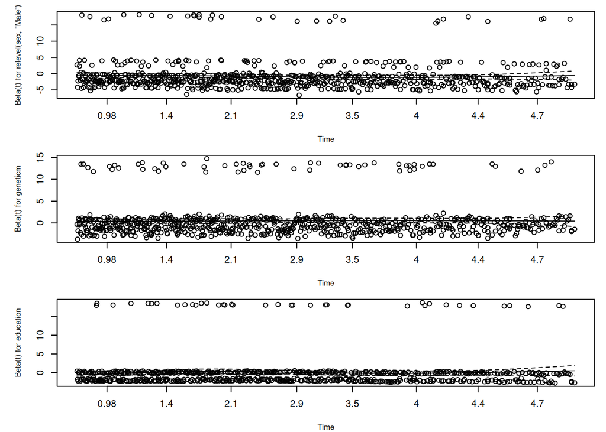

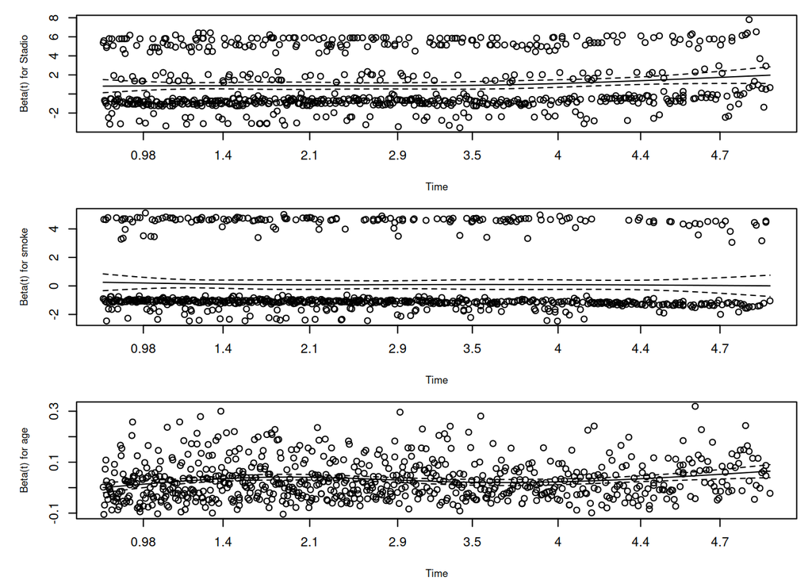

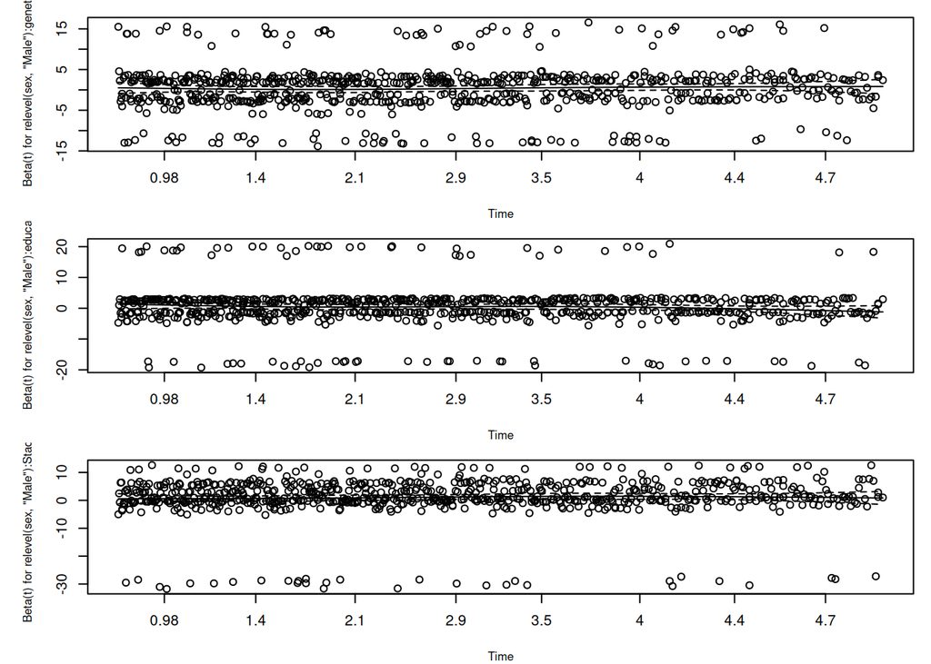

```r
par(mfrow=c(3,1), mar=c(4,5,1,1), cex.lab = 0.8)
plot(ph_test_2)
```

Anche in questo caso l’assunto di costanza dell’Hazard Ratio risulta verificato.